# Visualization for Airplanes Crashes

2023-06-23

## Total Crashes by Year

- Tendencia creciente a tener más accientes
- También ha aumentado el uso de los aviones para realizar viajes

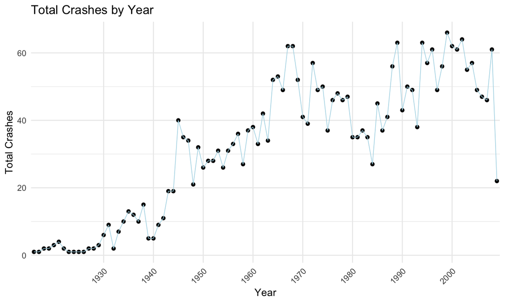

## Total Crashes Periodically

- No se observa ningún més con una tendencia mayor a los demás
- Tampoco se observa una tendencia mayor en ninguno de los días de la semana

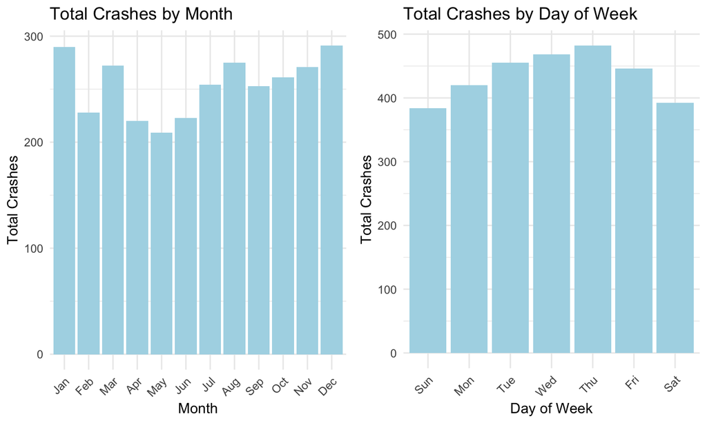

## Total Crashes Per Operator

- Se observa como en el global de accidentes de avión la mayoria son de operadoras comerciales
- Existe un período donde los accidentes militares son más comunes que no los accidentes comerciales

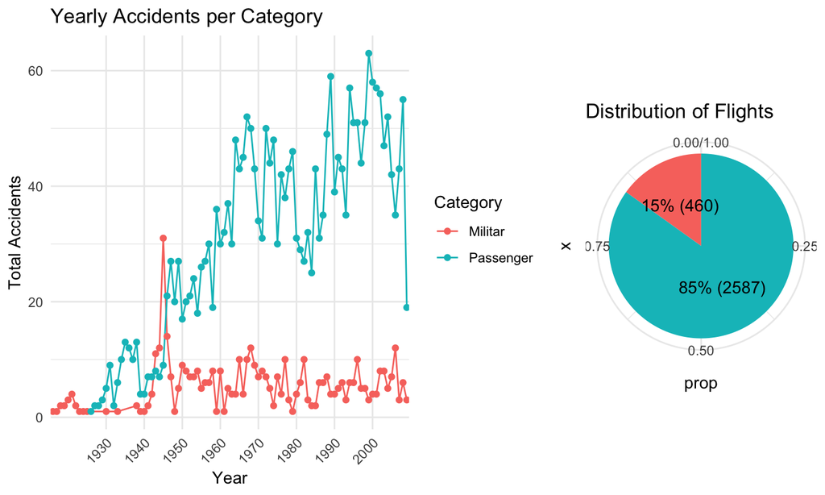

## World Crashes

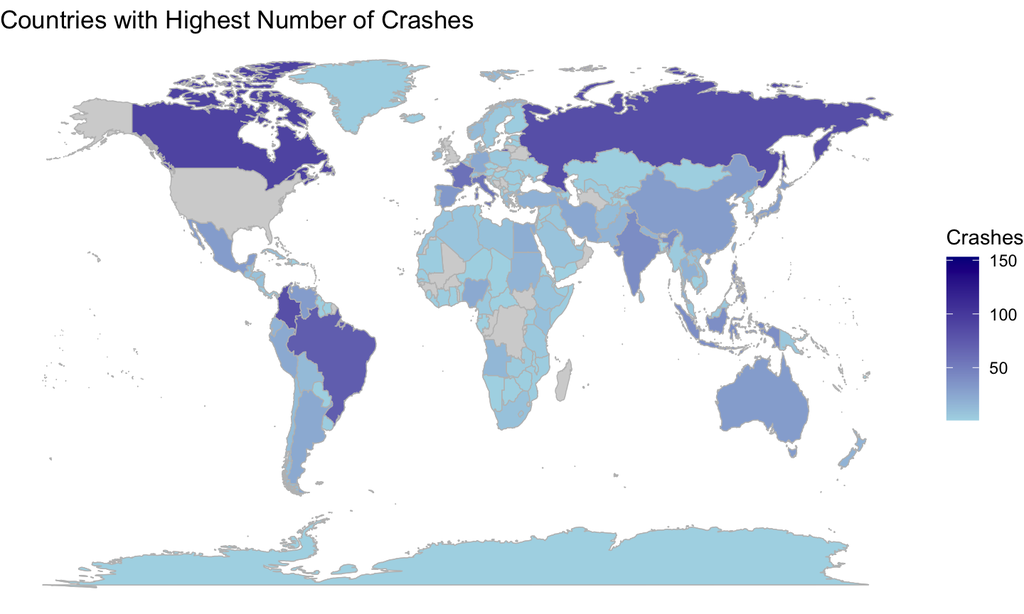

## Top 10 regions

Este top 10 de regiones representa un **27.2%** de las colisiones totales de aviones

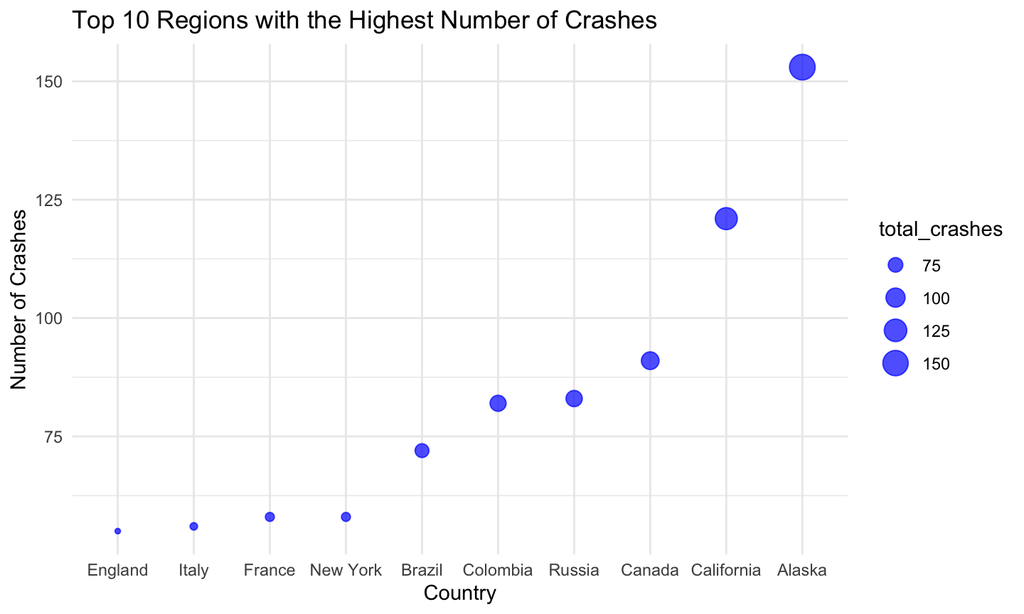

## Total Fatalities by Airplane Crashes per Year

- Aumento de las muertes por accidentes de avión

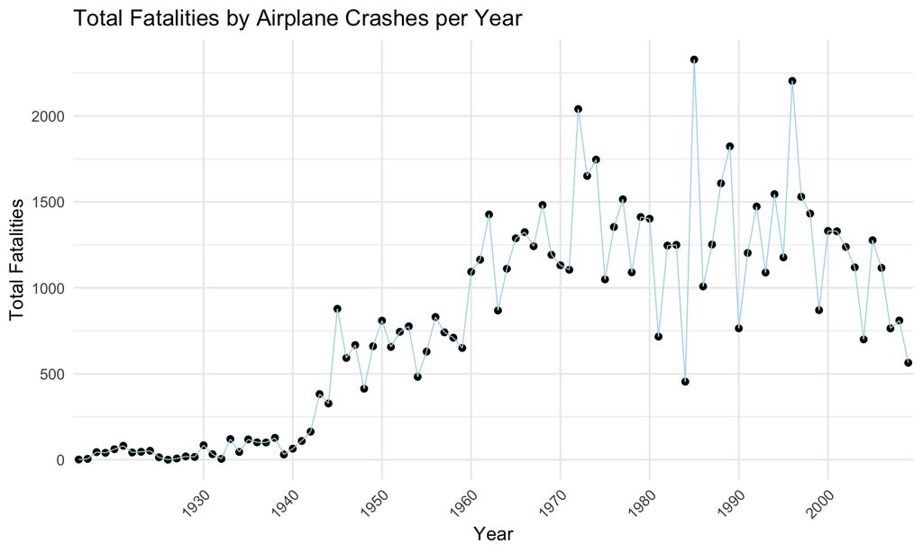

## Average Fatalities by Airplane Crashes by Year

- Pero si comparamos la media de muertes por accidente vemos como la tendencia se mantiene estable al largo del periodo

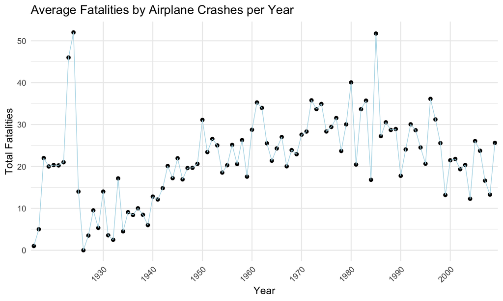

## Evolution of Survivors by Year

- Además viendo como cada vez los aviones son más grandes y se usan más, es más probable que muera más gente

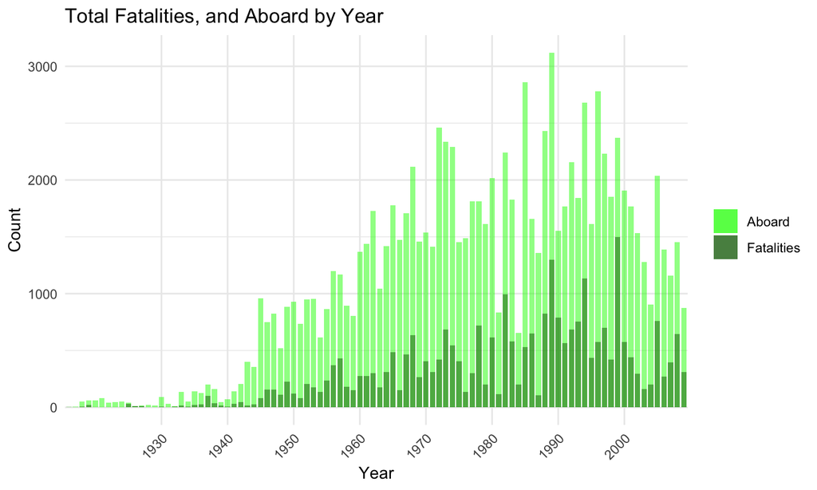

## Evolution of Survivors by Year

- Pero parece que la tasa de supervivencia es mayor actualmente que en el pasado

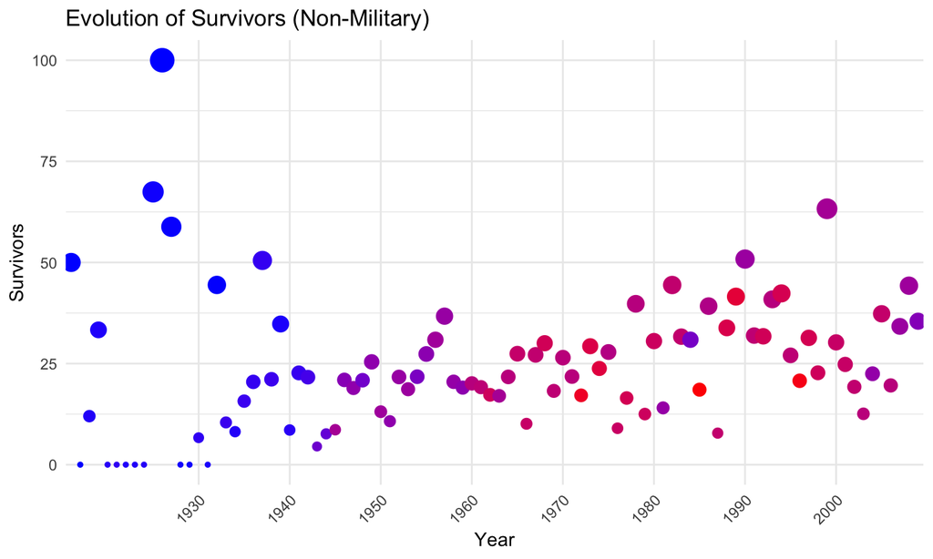

## Worldcloud

Hemos realizado un estudio de la variable Summary.

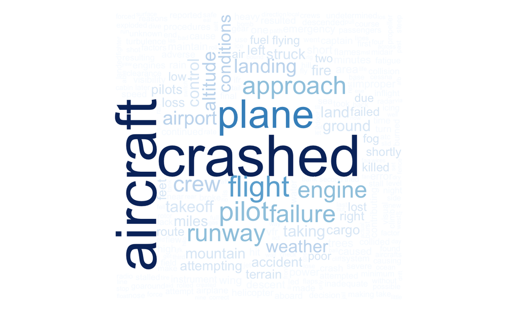

## Gracias por su atención!